## Capítulo 2 - Gráficos com plot() 01

## a - *plot()* ando gráficos

**pacotes a serem instalados/carregados: insuranceData**

A criaçao de gráficos é uma arte e um processo totalmente interativo e iterativo enquanto encontramos, modificando diversos argumentos, a aparência final do nosso gráfico.

Ainda que apenas para conhecer ou explorar os dados, a interação com o gráfico nos permite diferentes visões dos dados e começar a decidir sobre o tipo e apariencia dos gráficos finais.

Nos exercícios, as instruções que tenham a formatação exemplificada abaixo devem ser executadas no fragmento de código R que segue ou na consola do RStudio (janela 3).

#### *seguinte formatação*

Para ver algumas das possibilidades da função **plot()** execute na consola o seguinte comando:

**demo(“graphics”)**

#### Criação rápida de gráficos

A função *plot()* do R base, permite elaborar em forma rápida e simples, diversos gráficos que facilitam a análise exploratória de dados. Esses gráficos não são complexos ou aprimorados como para apresentações ou publicações, mas são extremamente úteis para definir análises iniciais e ainda definir o tipo de gráfico mais adequado para a elaboração de resultados finais.

A função é genérica e, acorde os dados de entrada, podemos ter diferentes tipos de gráficos.

A forma mais básica é *plot(x, y, …)*. Sendo *“…”* argumentos adicionais que podem ser definidos.

Vejamos o exemplo, usando o conjunto de dados “cars”:

```r
head(cars)
```

```
##   speed dist
## 1     4    2
## 2     4   10
## 3     7    4
## 4     7   22
## 5     8   16
## 6     9   10
```

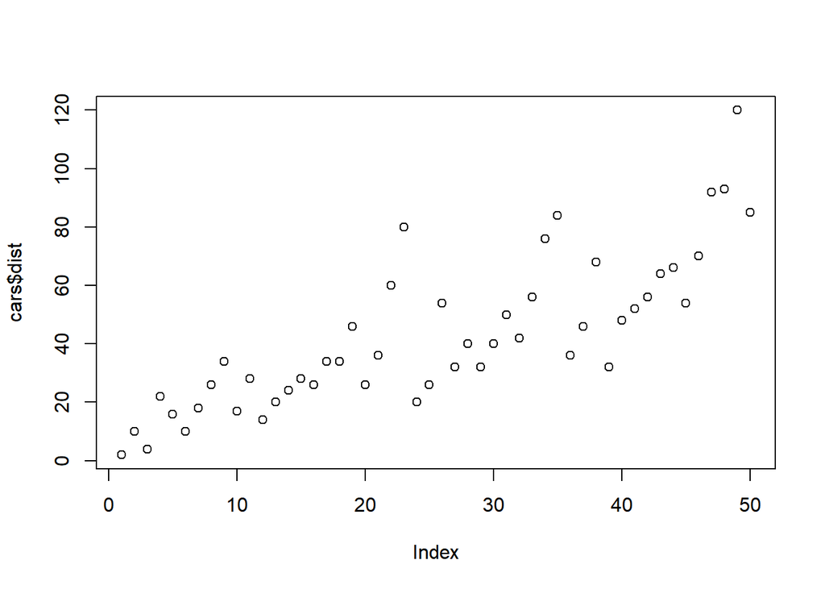

```r
plot(cars$dist)
```

Quando desejamos um gráfico de duas variáveis (uma explicatória ou independente no eixo x e uma explicada ou resposta no eixo y), basta fazer:

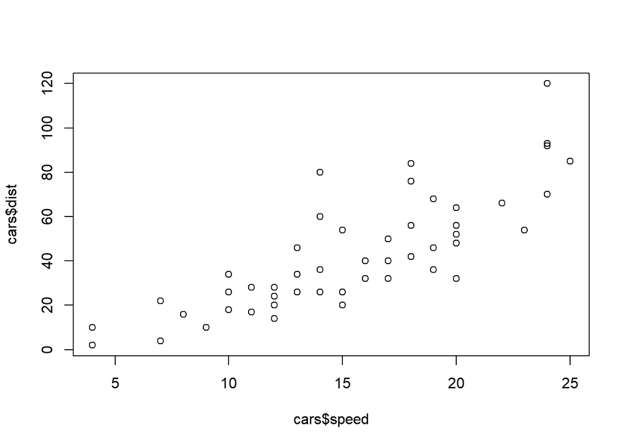

```r
plot(cars$speed, cars$dist)
```

Note em ambos casos que *plot()* escolheu automaticamente diversos atributos do gráfico para a plotagem.

#### Temos duas maneiras de especificar nossos dados ou variáveis: ou na forma cartesiana, **x, y**, como nos exemplos anteriores ou na forma de fórmula **y ~ x**.

#### Note a ordem das variáveis em cada uma e o uso do **~**.

Veja o seguinte exemplo com os dados do conjunto de dados **iris**:

```r
str(iris)
```

```
## 'data.frame':    150 obs. of  5 variables:
##  $ Sepal.Length: num  5.1 4.9 4.7 4.6 5 5.4 4.6 5 4.4 4.9 ...
##  $ Sepal.Width : num  3.5 3 3.2 3.1 3.6 3.9 3.4 3.4 2.9 3.1 ...
##  $ Petal.Length: num  1.4 1.4 1.3 1.5 1.4 1.7 1.4 1.5 1.4 1.5 ...
##  $ Petal.Width : num  0.2 0.2 0.2 0.2 0.2 0.4 0.3 0.2 0.2 0.1 ...
##  $ Species     : Factor w/ 3 levels "setosa","versicolor",..: 1 1 1 1 1 1 1 1 1 1 ...
```

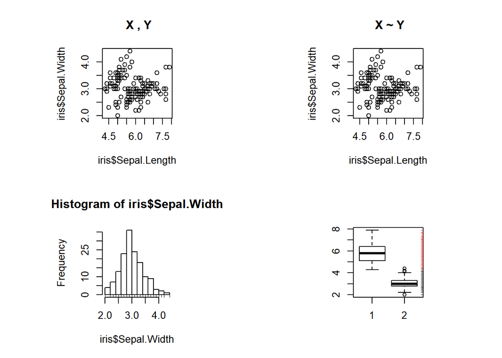

```r
par(mfrow = c(2, 2), pty = "s")

plot(iris$Sepal.Length, iris$Sepal.Width,  main = " X , Y")

plot(iris$Sepal.Width ~ iris$Sepal.Length, main = " X ~ Y")

hist(iris$Sepal.Width)

rug(iris$Sepal.Width)
boxplot(iris$Sepal.Length, iris$Sepal.Width)

rug(iris$Sepal.Length, side = 4, col = "red") # função que plota as observações no eixo (padrão=1)
rug(iris$Sepal.Width,  side = 4)
```

No painel anterior o parâmetro **par** determina como vamos configurar o espaço gráfico. O argumento *mfrow = c(2,2)*, indica que vamos ter 4 gráficos, organizados numa matriz de 2 linhas por 2 colunas. O preenchimento dos espaços pelos gráficos, por padrão, é por linha. A inclusão do argumento *pty = “s”*, faz que os gráficos mantenham um aspecto similar para ambos eixos (gráfico quadrado).

Também observa-se que a própria função *plot()* escolhe em forma automática os atributos de exibição dos gráficos, como limites dos eixos x e y, nomes das variáveis, forma, tamanho e cores dos pontos. boxplot.

Os títulos nos dois primeiros gráficos foram definidos através do argumento *main*.

Os argumentos adicionais que podem ser passados na função *plot()* são:

1- *type*, tipo de gráfico que queremos. Por padrão será usado “p” de pontos, mas temos:

- “l” para linhas;
- “b” para pontos e linhas;
- “c” para as linhas apenas da opção “b”;
- “o” para sobreposição de ambos;
- “h” para gráfico tipo ‘histograma’(linhas verticais);
- “s” degraus,
- “S” outros tipos de degraus
- “n” não plotar

2- *main*, título principal;

3- *sub*, subtítulo, debaixo do principal. Se aconselha para colocar a fonte dos nossos dados;

4- *xlab*, título do eixo x;

5- *ylab*, título do eixo y;

6- *xlim*, vetor que indica os limites mínimo e máximo do eixo x;

7- *ylim*, vetor que indica os limites mínimo e máximo do eixo y;

8- *pch*, determina o tipo de símbolo a ser usado, veja ?pch

9, *col*, cor da simbologia (em inglês), exemplo *col = “blue”*

**DICA**

Para a verificação dos exercícios, vai encontrar no seu diretório de trabalho um script Rmarkdown, “plot_exercicios.RMD”. No futuro podem ser uma referência, junto com o material da oficina para resolver em forma rápida problemas de visualização de dados.

#### *Exercício 01*

Usando o comando apresentado anteriormente:

*plot(cars$speed, cars$dist)*

1- Adicione título principal, subtítulo (sugestão: “Fonte: R datasets::cars”), legendas em ambos os eixos e redefina os limites de cada um.

2- Mude o tipo de símbolo para um triângulo preenchido com cor vermelha.

**Solução**

```r
# sua solução
```

#### *Exercício 02a*

Considerando o comando *hist* no segundo exemplo apresentado, fazer o histograma da variável *Sepal.Lenght* dos dados *iris*.

Redefina os limites dos eixos; coloque um título principal, um subtítulo e os nomes nos eixos; e defina uma cor verde para o histograma.

```r
# sua solução
```

A função *hist* escolhe automaticamente o número de intervalos ótimo, em função do tamanho da amostra e a dispersão dos dados, porém nem sempre é a melhor escolha visual. Através do argumento *breaks* e o número de intervalos desejado podemos mudar nosso histograma.

#### *Exercício 02b*

Com o comando do exercício anterior, experimente usar o argumento *breaks* com 5,10,20 e 50 intervalos. O que acontece com o eixo de frequências? E com 50 intervalos, o que acontece com o histograma?

```r
# sua solução
```

#### Gráficos de probabilidade amostral e histogramas

Ainda que não tão conhecidos como os histogramas, as probabilidades calculadas podem se tornar gráficos como um histograma “suavizado”, o que fornece uma melhor estimativa da função de probabilidade para uma variável aleatória.

A função *hist* com o argumento *“probability =T”*, calcula a função de probabilidade amostral e fornece os valores de densidade no eixo “y”. Adicionando uma linha de densidade sobre o histograma, a linha pode ser vista com um histograma “suavizado”.

Para isto, após o gráfico do histograma, adicione uma linha com a função lines e a densidade calculada. No exemplo a seguir, adicionamos uma linha em vermelho de largura = 2 e retiramos os limites do eixo “y”. A função *lines()* é uma função adicional que se coloca fora da função *plot()*.

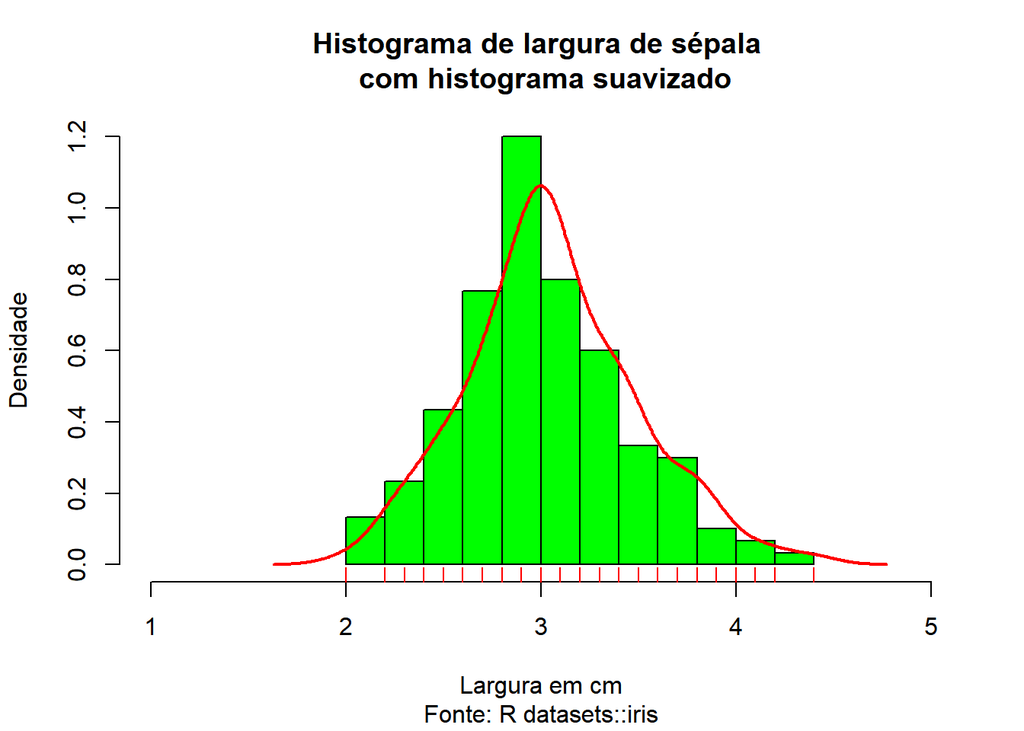

```r
hist(iris$Sepal.Width,
     probability = T,
     breaks      = 10,
     xlim        = c(1,5),
     main        = "Histograma de largura de sépala \n com histograma suavizado",
     sub         = "Fonte: R datasets::iris",
     xlab        = "Largura em cm",
     ylab        = "Densidade",
     col         = "green")
lines(density(iris$Sepal.Width), lwd=2, col= "red")

rug(iris$Sepal.Width, lwd = 1, col ="red")
```

Um outro tipo de gráfico muito usado é o de **barra**. que serve para mostrar as quantidades de observações contidas nos diferentes níveis de uma variável categórica. Nos dados *iris* a função *table(iris$Species)* (execute na consola de comandos), nos informa que as três espécies da planta tem 50 observações cada. função *plot()* pode fazer um gráfico de barras, mas visualmente não é atrativo.

#### *Exercício 03*

Veja o seguinte exemplo, experimentando na linha de comando:

plot(table(iris$Species))

A função específica *barplot()* elabora a partir de uma tabela prévia, o gráfico de barras correspondente. Vejamos agora a mesma tabela com a função *barplot*:

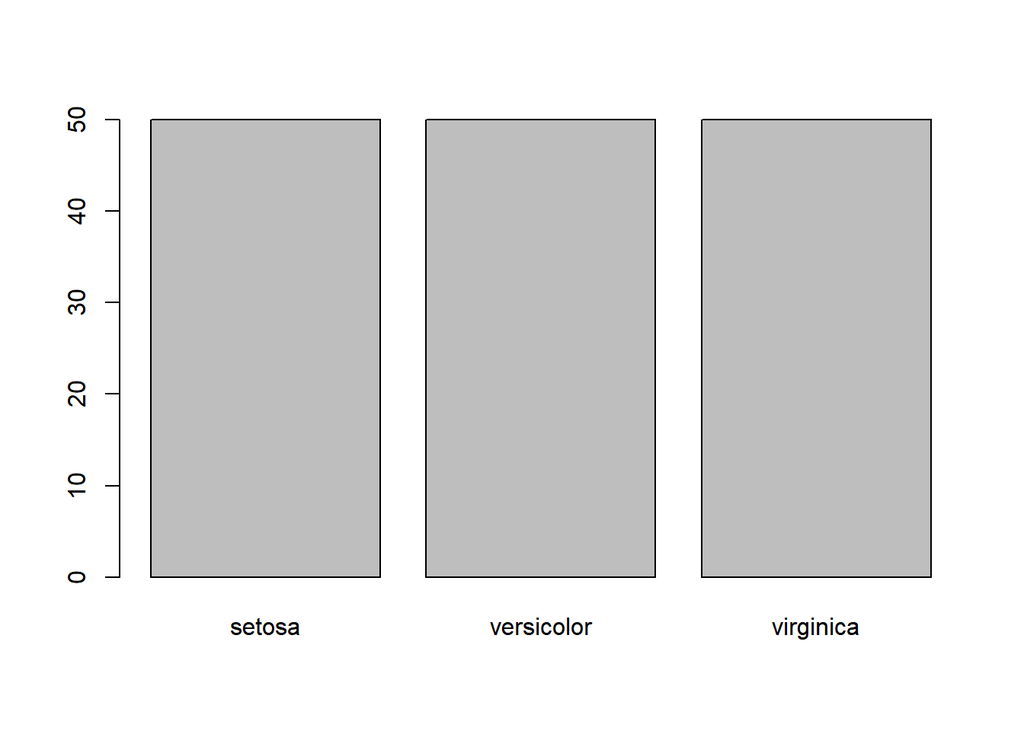

```r
barplot(table(iris$Species))
```

#### *Exercício 04*

Com os conhecimentos de argumentos já conhecidos: coloque título principal, subtítulo, nome no eixo “y” e dê uma cor diferente para cada barra. Dica: o argumento *col* aceita um vetor com os nomes das cores em inglês, tipo *c(“cor1”, “cor2”,…)*.

Finalmente algumas considerações acerca do tipo de gráfico de torta ou *pie chart*. Ele pode ser usado quando as categorias a serem mostradas são em número pequeno e não muito diferentes nas suas quantidades ou valores.

Para ter categorias em número diferentes, vamos usar a base de dados *mtcars* e fazer uma tabela de carros por tipo de quantidade de marchas (3, 4 ou 5). Logo após vamos apresentar a tabela e o gráfico com *barpot()* e com *pie* lado a lado *(mfrow)*.

```r
tab <- table (mtcars$gear)
tab
```

```
##
##  3  4  5
## 15 12  5
```

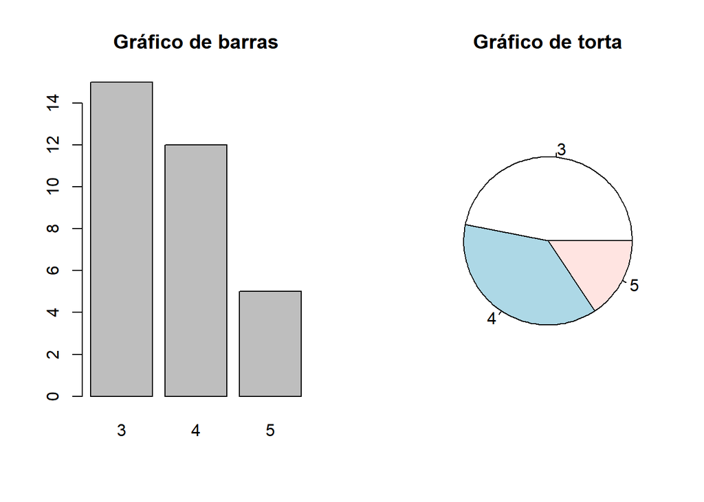

```r
# Configurando o espaço gráfico para dois gráficos na mesma linha
par(mfrow = c(1,2))

barplot(tab, main="Gráfico de barras")
pie(tab, main="Gráfico de torta")
```

No exemplo apresentado, a informação tem diferentes características.

No primeiro gráfico, pode-se estimar pelo eixo *y* a quantidade de dados em cada categoria, assim como temos a impressão do tamanho relativo de cada uma.

No segundo gráfico, temos uma visão mais clara do tamanho relativo, mas não temos as quantidades.

Ambas as dificuldades podem ser contornadas com a inclusão de argumentos adicionais em cada função. Porém, o gráfico de torta fica comprometido no caso de maior número de variáveis e grande diferença de elementos entre as categorias.

No exemplo abaixo, usaremos uma base de dados de seguros de carros e criar uma tabela por tipo de carro. Na sequência, vamos plotar dois gráficos: barras com *barplot()* e *pie*.

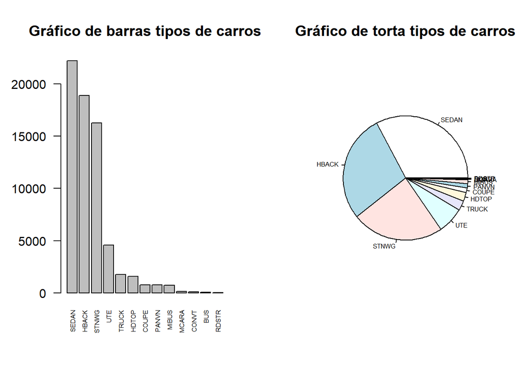

```r
# Carrega o pacote insuranceData
library(insuranceData)

# Uso a função "data" para carregar a base "dataCar" do pacote "insuranceData"
data("dataCar")

# Configurando o espaço gráfico para dois gráficos na mesma linha
par(mfrow = c(1,2))

# Criar a tabela de tipo de carro e ordenar em ordem decrescente
tab <- sort(table(dataCar$veh_body),
            decreasing = T)

# Gráfico de barras  com nomes reduzidos pela metade cex.names = 0.5
# o argumento las = 2, coloca os nomes na vertical para melhorar o espaço
barplot(tab, las = 2, cex.names = 0.5)

# Adiciono um título, usando a função "title"
title("Gráfico de barras tipos de carros")

# criar o gráfico de torta
pie(tab, cex = 0.5)
title("Gráfico de torta tipos de carros")
```

Apesar da grande diferença de dados em cada variável, vemos que no caso do gráfico de barras ainda temos uma visão clara do tamanho relativo, assim como das quantidades envolvidas. No caso do gráfico de torta, a leitura torna-se impossível para as menores quantidades, sobrepondo as últimas. A escolha da melhor apresentação é uma tarefa subjetiva, porém em toda a literatura de visualização de dados não se recomenda usar o gráfico de torta e, se ainda assim for usado, **nunca colocá-lo em 3D**.

FIM DA PRIMEIRA PARTE